# Monitoring Mangrove Extents

## Background

[Global Mangrove Watch (GMW)](https://www.globalmangrovewatch.org/) is an initiative to track global mangrove extents. Using ALOS PALSAR and Landsat (optical) data to form a baseline extent of mangroves for the years 1996, 2007, 2008, 2009, 2010, 2015, and 2016 . More detailed information on the initiative can be found [here](http://data.unep-wcmc.org/datasets/45).

## Description

The goal of this notebook is to monitor the changing extent of mangroves, using the GMW layers as a baseline mask.

The process begins with retrieving Sentnel-2 data for a specific area in a time series. This dataset is then compressed into a median composite for each year. From the composite, we then calculate the NDVI values of each pixel in each year. The dataset is then masked, and the NDVI threshold is applied for mangrove classification. The following image shows the decision tree for the classification.

[figure not shown]

After classification, we can perform a variety of analyses on the data:

- We can estimate the change in mangrove areas by counting all the classified pixels for each year and plotting the trend line of the count.
- We can also visualize the mangrove areas by plotting each classified pixel a certain color.

## Getting started

**To run this analysis**, run all the cells in the notebook, starting with the Load packages cell.

**After finishing the analysis**, return to the Analysis parameters cell, modify some values (e.g. choose a your own mangrove shapefile or time period to analyse) and re-run the analysis.

### Load packages

```python
%matplotlib inline

import warnings
import datacube
from datacube.utils import masking
import numpy as np
import pandas as pd
import xarray as xr
import geopandas as gpd
from requests import Request
import matplotlib.pyplot as plt
from datacube.utils import geometry
from matplotlib.patches import Patch
from matplotlib.colors import ListedColormap

from dea_tools.datahandling import mostcommon_crs
from dea_tools.plotting import display_map

import sys
try:
    from dea_tools.spatial import xr_rasterize
except ImportError:
    # Local copy of selected dea_tools
    if '../tools/' not in sys.path:
        sys.path.append('../tools/')
    from datacube_utils import xr_rasterize
```

### Set up a Dask cluster

Dask can be used to better manage memory use down and conduct the analysis in parallel.

To use Dask, set up the local computing cluster using the cell below.

```python
from datacube.utils.dask import start_local_dask

client = start_local_dask()

display(client)
```

```
2022-07-22 06:37:36,227 - distributed.diskutils - INFO - Found stale lock file and directory '/tmp/dask-worker-space/worker-q3na5riy', purging
```

Client

Client-c5995fe8-0988-11ed-a786-225aab3fba0b

| **Connection method:** Cluster object | **Cluster type:** distributed.LocalCluster |
| --- | --- |
| **Dashboard:** /user/cadams/proxy/8787/status |  |

**Cluster Info**

LocalCluster

b4f2f20e

| **Dashboard:** /user/cadams/proxy/8787/status | **Workers:** 1 |
| --- | --- |
| **Total threads:** 8 | **Total memory:** 27.51 GiB |
| **Status:** running | **Using processes:** True |

**Scheduler Info**

Scheduler

Scheduler-4aefc92d-6f28-4923-96ef-f3f961832f95

| **Comm:** tcp://127.0.0.1:37417 | **Workers:** 1 |
| --- | --- |
| **Dashboard:** /user/cadams/proxy/8787/status | **Total threads:** 8 |
| **Started:** Just now | **Total memory:** 27.51 GiB |

**Workers**

**Worker: 0**

| **Comm:** tcp://127.0.0.1:46771 | **Total threads:** 8 |
| --- | --- |
| **Dashboard:** /user/cadams/proxy/32937/status | **Memory:** 27.51 GiB |
| **Nanny:** tcp://127.0.0.1:42659 |  |
| **Local directory:** /tmp/dask-worker-space/worker-2d7e9zmu |  |

### Load the data

Connect to the datacube database and set up a processing cluster.

```python
dc = datacube.Datacube(app="Mangrove")
```

### Analysis parameters

**If running the notebook for the first time**, keep the default settings below. This will demonstrate how the analysis works and provide meaningful results.

```python
top, left = 8.654161, 104.714182
bottom, right = 8.628812, 104.746726

lat_range = (bottom, top)
lon_range = (left, right)

product_name = "s2_l2a"

time_range = ("2017", "2022")
```

### View the selected location

The next cell will display the selected area on an interactive map. Feel free to zoom in and out to get a better understanding of the area you'll be analysing. Clicking on any point of the map will reveal the latitude and longitude coordinates of that point.

```python
display_map(lon_range, lat_range)
```

Make this Notebook Trusted to load map: File -> Trust Notebook

[interactive chart not shown]

## Load cloud-masked Sentinel-2 data

```python
# General query
query = {
    "time": time_range,
    'x': lon_range,
    'y': lat_range,
}

# Identify the most common CRS
common_crs = mostcommon_crs(dc, product_name, query)
print(f"Selected CRS: {common_crs}")

# Update the query with additional parameters
query.update(
    {
        "product": product_name,
        "measurements": ["red", "nir_1", "mask"],
        "group_by": "solar_day",
        "resolution": (-10, 10),
        "output_crs": common_crs,
        "dask_chunks": {"time": 1, "x": -1, "y": -1}
    }
)
```

```
Selected CRS: EPSG:32648
```

```python
ds_s2 = dc.load(**query)

ds_s2
```

```
<xarray.Dataset>
Dimensions:      (time: 314, y: 281, x: 359)
Coordinates:
  * time         (time) datetime64[ns] 2017-01-01T03:33:42 ... 2022-04-30T03:...
  * y            (y) float64 9.566e+05 9.566e+05 ... 9.538e+05 9.538e+05
  * x            (x) float64 4.686e+05 4.686e+05 ... 4.721e+05 4.721e+05
    spatial_ref  int32 32648
Data variables:
    red          (time, y, x) uint16 dask.array<chunksize=(1, 281, 359), meta=np.ndarray>
    nir_1        (time, y, x) uint16 dask.array<chunksize=(1, 281, 359), meta=np.ndarray>
    mask         (time, y, x) uint8 dask.array<chunksize=(1, 281, 359), meta=np.ndarray>
Attributes:
    crs:           EPSG:32648
    grid_mapping:  spatial_ref
```

### Masking

Clouds, cloud shadows, and other invalid pixels need to be removed before conducting the analysis.

The first step in masking is to identify the information in the masking band. This can be done using the `masking.describe_variable_flags)` function:

```python
masking.describe_variable_flags(ds_s2.mask)
```

|  | bits | values | description |
| --- | --- | --- | --- |
| qa | [0, 1, 2, 3, 4, 5, 6, 7] | {'0': 'no data', '1': 'saturated or defective'... | Sen2Cor Scene Classification |

For Sentinel-2 in the Asia EASI Hub, the masking information is stored in the **values** column of the **qa** row in this dataframe. To get a better look at the types of pixel classifications this mask has, we can display the values column:

```python
masking.describe_variable_flags(ds_s2.mask).loc["qa", "values"]
```

```
{'0': 'no data',
 '1': 'saturated or defective',
 '2': 'dark area pixels',
 '3': 'cloud shadows',
 '4': 'vegetation',
 '5': 'bare soils',
 '6': 'water',
 '7': 'unclassified',
 '8': 'cloud medium probability',
 '9': 'cloud high probability',
 '10': 'thin cirrus',
 '11': 'snow or ice'}
```

We can now construct a mask of valid pixel classes. In this case, we say that `vegetation`, `bare soils`, `water`, or `snow or ice` are valid, cloud-free pixels:

```python
# Multiple flags are combined as logial OR using the | symbol
cloud_free_mask = (
    masking.make_mask(ds_s2.mask, qa="vegetation") |
    masking.make_mask(ds_s2.mask, qa="bare soils") |
    masking.make_mask(ds_s2.mask, qa="water") |
    masking.make_mask(ds_s2.mask, qa="snow or ice")
)
```

The final step is to mask the data.

```python
# Mask the data
ds_s2 = ds_s2.where(cloud_free_mask)
```

```python
# View the loaded data

ds_s2
```

```
<xarray.Dataset>
Dimensions:      (time: 314, y: 281, x: 359)
Coordinates:
  * time         (time) datetime64[ns] 2017-01-01T03:33:42 ... 2022-04-30T03:...
  * y            (y) float64 9.566e+05 9.566e+05 ... 9.538e+05 9.538e+05
  * x            (x) float64 4.686e+05 4.686e+05 ... 4.721e+05 4.721e+05
    spatial_ref  int32 32648
Data variables:
    red          (time, y, x) float64 dask.array<chunksize=(1, 281, 359), meta=np.ndarray>
    nir_1        (time, y, x) float64 dask.array<chunksize=(1, 281, 359), meta=np.ndarray>
    mask         (time, y, x) float64 dask.array<chunksize=(1, 281, 359), meta=np.ndarray>
Attributes:
    crs:           EPSG:32648
    grid_mapping:  spatial_ref
```

## Load in the Global Mangrove Watch

Below we load the latest GMW layer, which is from 2016. We send a query to the [EASI Geoserver](https://geoserver.asia.easi-eo.solutions/), requesting the data using the `wfs_request_params` dictionary below.

```python
WFS_URL = "https://geoserver.asia.easi-eo.solutions/geoserver/ows?"
WFS_LAYER = "unep-wcmc:GMW_2016_v2"

wfs_request_params = {
    "service": "WFS",
    "version": "1.0.0",
    "request": "GetFeature",
    "typeName": WFS_LAYER,
    "outputFormat": "json",
    "bbox": f"{left},{bottom},{right},{top},EPSG:4326"
}

# Parse the URL with parameters
request_url = Request("GET", WFS_URL, params=wfs_request_params).prepare().url

# Read the data
gmw_2016_gdf = gpd.read_file(request_url)

# Examine first five rows of the data
gmw_2016_gdf.head()
```

|  | id | ogc_fid | pxlval | geometry |
| --- | --- | --- | --- | --- |
| 0 | GMW_2016_v2.328868 | 328868 | 1 | MULTIPOLYGON (((104.88620 8.68930, 104.88640 8... |

```python
# Display loaded data on interactive map
gmw_2016_gdf.explore()
```

Make this Notebook Trusted to load map: File -> Trust Notebook

[interactive chart not shown]

## Combine observations into noise-free summary images

In the code below, we take the time series of images and combine them into single images for each year using the `median NDVI`. The *Normalised Difference Vegetation Index* (NDVI) shows vegetation and is used for mangrove classification within the mangrove mask.

$$ \begin{aligned} \text{NDVI} & = \frac{(\text{NIR} - \text{Red})}{(\text{NIR} + \text{Red})} \\ \end{aligned} $$

For more information on indices, see the Calculating Band Indices notebook.

> Note: This step can take several minutes to load if the study area is large. We recommend opening the Dask processing window to view the different computations that are being executed; to do this, see the Dask dashboard in DE Africa section of the Dask notebook.

```python
# Calculate MNDWI and add it to the loaded data set
ds_s2["NDVI"] = (ds_s2.nir_1 - ds_s2.red)/(ds_s2.nir_1 + ds_s2.red)
```

```python
# generate median annual summaries of NDVI
ds_summaries = ds_s2.NDVI.groupby("time.year").median().compute()
```

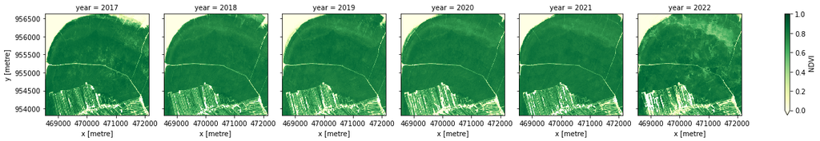

```python
# Plot the output summary images
ds_summaries.plot(col="year", cmap="YlGn", col_wrap=len(ds_summaries.year.values), vmin=0, vmax=1.0);
```

## Mangrove classification

### Apply a mask of the mangrove area

We will use the mangrove mask from the Global Mangrove Watch dataset so we can work with only the pixels in the mangrove area.

```python
gmw_2016_raster = xr_rasterize(
    gdf=gmw_2016_gdf,
    da=ds_summaries,
    transform=ds_summaries.geobox.transform,
    crs=common_crs
)
```

```python
# Mask dataset to set pixels outside the GMW layer to `NaN`
ds_summaries_masked = ds_summaries.where(gmw_2016_raster)
```

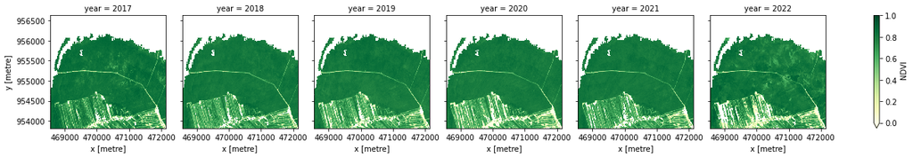

```python
# Plot the output summary images
ds_summaries_masked.plot(col="year", cmap="YlGn", col_wrap=len(ds_summaries.year.values), vmin=0, vmax=1.0);
```

### Calculating regular and closed mangroves

Using the mangrove decision tree above, we can classify the pixels as:

- **mangroves:** pixels in the mangrove area with an `NDVI > 0.4`
  - **regular mangroves:** mangroves with `NDVI <= 0.7`
  - **closed mangroves:** mangroves with `NDVI > 0.7`

```python
all_mangroves = xr.where(ds_summaries_masked > 0.4, 1, np.nan)

regular_mangroves = all_mangroves.where(ds_summaries_masked <= 0.7)
closed_mangroves = all_mangroves.where(ds_summaries_masked > 0.7)
```

### Plot the mangrove types

Again we will combine the mangrove types for easier plotting.

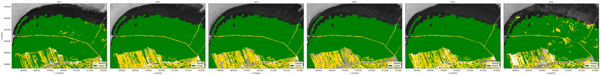

```python
mangroves = xr.concat(
    [regular_mangroves, closed_mangroves, all_mangroves],
    dim=pd.Index(["regular", "closed", "total"], name="mangrove_type"),
)

regular_color = "gold"
closed_color = "green"

# Create a FacetGrid, so there is a subplot for each year
grid = xr.plot.FacetGrid(
    mangroves,
    col="year",
    col_wrap=len(ds_summaries.year.values),
    size=6,
    aspect=mangroves.x.size / mangroves.y.size,
)

# Define the sub-plot of mangrove types with a legend on a background of grey-scale NDVI
def plot_mangrove(data, ax, **kwargs):
    ds_summaries.sel(year=data.year).plot.imshow(
        ax=ax, cmap="Greys", vmin=-1, vmax=1, add_colorbar=False, add_labels=False
    )
    data.sel(mangrove_type="regular").plot.imshow(
        ax=ax,
        cmap=ListedColormap([regular_color]),
        add_colorbar=False,
        add_labels=False,
    )
    data.sel(mangrove_type="closed").plot.imshow(
        ax=ax, cmap=ListedColormap([closed_color]), add_colorbar=False, add_labels=False
    )

    ax.legend(
        [Patch(facecolor=regular_color), Patch(facecolor=closed_color)],
        ["Regular", "Closed"],
        loc="lower right",
    )

# Plot the each year sub-plot
grid.map_dataarray(plot_mangrove, x="x", y="y", add_colorbar=False)

# Update sub-plot titles
for i, name in np.ndenumerate(grid.name_dicts):
    grid.axes[i].title.set_text(str(name["year"]));
```

## Mangrove change

### Plot the change of mangrove classification in area over time

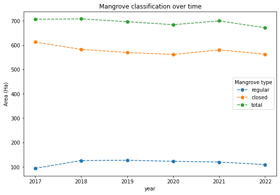

```python
# Convert pixel count to km^2
m2_per_ha = 10000
m2_per_pixel = query["resolution"][1] ** 2
mangrove_area = mangroves.sum(dim=("x", "y")) * m2_per_pixel / m2_per_ha

# Fix axis and legend text
mangrove_area.name = r"Area (Ha)"
mangrove_area = mangrove_area.rename(mangrove_type="Mangrove type")

# Plot the line graph
mangrove_area.plot(
    hue="Mangrove type",
    x="year",
    xticks=mangrove_area.year,
    size=6,
    linestyle="--",
    marker="o",
)
plt.title("Mangrove classification over time");
```

### Monitoring change in mangroves

We can calculate the growth and loss of mangroves between the first and last year in our timeseries

```python
total_mangroves = (mangroves.loc["total"] == 1).astype(int)

# Calculate the change in mangrove extent
old = total_mangroves.isel(year=0)
new = total_mangroves.isel(year=-1)
change = new - old

# reclassify into growth, loss and stable
growth = xr.where(change == 1, 1, np.nan)
loss = xr.where(change == -1, -1, np.nan)
stable = old.where(~change)
stable = xr.where(stable == 1, 1, np.nan)
```

#### Plot the change

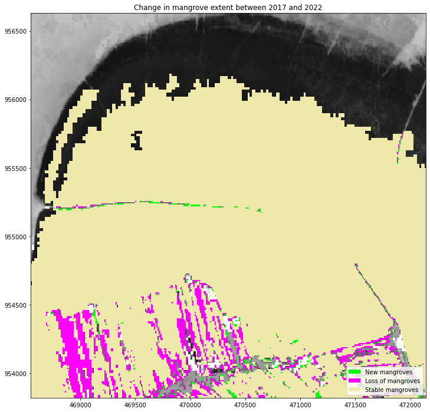

```python
fig, ax = plt.subplots(1, 1, figsize=(12, 12))

ds_summaries.isel(year=0).plot.imshow(
    ax=ax, cmap="Greys", vmin=-1, vmax=1, add_colorbar=False, add_labels=False
)
stable.plot(
    ax=ax, cmap=ListedColormap(["palegoldenrod"]), add_colorbar=False, add_labels=False
)
growth.squeeze().plot.imshow(
    ax=ax, cmap=ListedColormap(["lime"]), add_colorbar=False, add_labels=False
)
loss.plot.imshow(
    ax=ax, cmap=ListedColormap(["fuchsia"]), add_colorbar=False, add_labels=False
)
ax.legend(
    [
        Patch(facecolor='lime'),
        Patch(facecolor='fuchsia'),
        Patch(facecolor="palegoldenrod"),
    ],
    ["New mangroves", "Loss of mangroves", "Stable mangroves"],
    loc="lower right",
)
plt.title('Change in mangrove extent between {} and {}'.format(ds_summaries.year.values[0], ds_summaries.year.values[-1]));
```

### Determine the net change between years

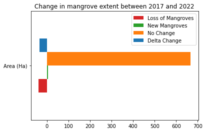

```python
loss_count = loss.sum().values * m2_per_pixel / m2_per_ha
gain_count = growth.sum().values * m2_per_pixel / m2_per_ha
stable_count = stable.sum().values* m2_per_pixel / m2_per_ha

counts = {
          'Loss of Mangroves': loss_count,
          'New Mangroves': gain_count,
          'No Change': stable_count,
          'Delta Change': gain_count + loss_count
          }

df = pd.DataFrame(counts, index=['Area (Ha)'])
df.plot.barh(color=['tab:red','tab:green','tab:orange','tab:blue'])
plt.title('Change in mangrove extent between {} and {}'.format(ds_summaries.year.values[0], ds_summaries.year.values[-1]));
```